# C-center models

# 1 Load required packages

```r
library(tidyr)
library(dplyr)
library(stringr)
library(lme4)
library(car)
library(visreg)
library(optimx)
library(lmerTest)
library(emmeans)
library(neldermead)
```

```r
library(ggplot2)
library(optimx)
library(mgcv)
library(itsadug)
```

# 2 Introduction

From the c-center hypothesis it follows that onsets are coordinated inphase with the following vowel, meaning that they are initiated roughly around the same time. On the other hand, multiple consonants in an onset are also coordinated antiphase with each other (i.e. sequential initiation). To cope with these competing relations, the leftmost C gets shifted towards the left and the rightmost C gets shifted towards the right (with respect to the following vowel) in complex onsets. In this way, the average onset of the two C’s is still initiated at the same time as the vowel, whereas they are also still coordinated in an antiphase relation with each other. Our hypothesis is that PD patients will show a stronger preference for the inphase relationship, coming at the cost of the antiphase relationship. In our data we’ve included three singular onsets /p/, /m/ and /x/ and four complex onsets: /sp/, /sm/, /sx/ and /spr/. The variable ‘time.lag.norm’ is the normalized time lag between the offset of the leftmost C and the onset of the rightmost C. If our hypothesis is correct the lag between the C’s should be lower for the PD group in comparison with the controls.

## 2.1 Read data

```r
df <- readRDS("../data/modelling_data_CC.rds")
```

## 2.2 Clean data

Remove all the rows that have NA in the dependent variable and drop ‘empty’ levels, convert variables to factors and create trimmed dataset.

```r
df <- df[complete.cases(df$time.lag.norm),]
df <- droplevels(df)

# Sort data
df <- df[order(df$subj, df$recording.no),]

# convert to factors/numeric
df$prompt <- as.factor(df$prompt)
df$condition <- as.factor(df$condition)

# remove all the recordings without a speech rate measure:
df <- df %>% drop_na(duration.tt)

# remove participants with only a few datapoints
#remove <- c("PD19", "CTRL19")
#df.trim <- df[! df$subj %in% remove, ]
#df.trim <- droplevels(df.trim)


# create df without sx
#df.trim <- df.trim[! df.trim$cluster == "sx", ]
#df.trim <- droplevels(df.trim)
#levels(df.trim$cluster)

# create df without spr
df.nospr <- df[! df$cluster == "spr", ]
df.nospr <- droplevels(df.nospr)
levels(df.nospr$cluster)
```

```
## [1] "sm" "sp" "sx"
```

```r
# Change order of levels in cluster
df$cluster <- factor(df$cluster, levels = c("sp", "sm", "sx", "spr"))
```

# 3 LME models for CC lag analysis (coarticulation)

If indeed patients would show a stronger preference for inphase coordination, this would mean that they would produce the C gestures in the syllable’s onset closer together in time. For this, we look at the lag between the gestural offset of the leftmost C and the gestural onset of the righmost C in complex clusters.

## 3.1 Hypothesis testing

Fitting first model, smooth over subject:

```r
summary(m <- gam(time.lag.norm ~ s(subj, bs='re'), data=df.nospr, method = "ML"))
```

```
##
## Family: gaussian
## Link function: identity
##
## Formula:
## time.lag.norm ~ s(subj, bs = "re")
##
## Parametric coefficients:
##             Estimate Std. Error t value Pr(>|t|)
## (Intercept)  0.24238    0.01764   13.74   <2e-16 ***
## ---
## Signif. codes:  0 '***' 0.001 '**' 0.01 '*' 0.05 '.' 0.1 ' ' 1
##
## Approximate significance of smooth terms:
##           edf Ref.df     F p-value
## s(subj) 35.52     46 3.907  <2e-16 ***
## ---
## Signif. codes:  0 '***' 0.001 '**' 0.01 '*' 0.05 '.' 0.1 ' ' 1
##
## R-sq.(adj) =  0.132   Deviance explained = 15.8%
## -ML = 199.28  Scale est. = 0.077175  n = 1185
```

Adding cluster as fixed effect:

```r
summary(m1 <- gam(time.lag.norm ~ s(subj,bs='re') + cluster, data=df.nospr, method = "ML"))
```

```
##
## Family: gaussian
## Link function: identity
##
## Formula:
## time.lag.norm ~ s(subj, bs = "re") + cluster
##
## Parametric coefficients:
##             Estimate Std. Error t value Pr(>|t|)
## (Intercept)  0.35372    0.01995   17.73  < 2e-16 ***
## clustersp   -0.06297    0.01702   -3.70 0.000226 ***
## clustersx   -0.31092    0.01823  -17.06  < 2e-16 ***
## ---
## Signif. codes:  0 '***' 0.001 '**' 0.01 '*' 0.05 '.' 0.1 ' ' 1
##
## Approximate significance of smooth terms:
##           edf Ref.df     F p-value
## s(subj) 37.35     46 5.099  <2e-16 ***
## ---
## Signif. codes:  0 '***' 0.001 '**' 0.01 '*' 0.05 '.' 0.1 ' ' 1
##
## R-sq.(adj) =   0.32   Deviance explained = 34.2%
## -ML = 58.892  Scale est. = 0.060508  n = 1185
```

```r
compareML(m,m1)
```

```
## m: time.lag.norm ~ s(subj, bs = "re")
##
## m1: time.lag.norm ~ s(subj, bs = "re") + cluster
##
## Chi-square test of ML scores
## -----
##   Model     Score Edf Difference    Df  p.value Sig.
## 1     m 199.28147   2
## 2    m1  58.89161   4    140.390 2.000  < 2e-16  ***
##
## AIC difference: 284.78, model m1 has lower AIC.
```

Sign. improvement.

Adding group as fixed effect:

```r
summary(m2 <- gam(time.lag.norm ~ s(subj,bs='re') + cluster + group, data=df.nospr, method = "ML"))
```

```
##
## Family: gaussian
## Link function: identity
##
## Formula:
## time.lag.norm ~ s(subj, bs = "re") + cluster + group
##
## Parametric coefficients:
##             Estimate Std. Error t value Pr(>|t|)
## (Intercept)  0.32059    0.02489  12.882  < 2e-16 ***
## clustersp   -0.06333    0.01702  -3.720 0.000209 ***
## clustersx   -0.31088    0.01823 -17.055  < 2e-16 ***
## groupPD      0.06918    0.03299   2.097 0.036202 *
## ---
## Signif. codes:  0 '***' 0.001 '**' 0.01 '*' 0.05 '.' 0.1 ' ' 1
##
## Approximate significance of smooth terms:
##           edf Ref.df     F p-value
## s(subj) 35.71     45 4.539  <2e-16 ***
## ---
## Signif. codes:  0 '***' 0.001 '**' 0.01 '*' 0.05 '.' 0.1 ' ' 1
##
## R-sq.(adj) =  0.319   Deviance explained = 34.2%
## -ML = 56.807  Scale est. = 0.060541  n = 1185
```

```r
compareML(m1,m2)
```

```
## m1: time.lag.norm ~ s(subj, bs = "re") + cluster
##
## m2: time.lag.norm ~ s(subj, bs = "re") + cluster + group
##
## Chi-square test of ML scores
## -----
##   Model    Score Edf Difference    Df p.value Sig.
## 1    m1 58.89161   4
## 2    m2 56.80702   5      2.085 1.000   0.041  *
##
## AIC difference: -0.12, model m1 has lower AIC.
```

Doesn’t improve enough (AIC diff < 2).

Adding cluster:group as fixed effect:

```r
summary(m3 <- gam(time.lag.norm ~ s(subj,bs='re') + cluster*group, data=df.nospr, method = "ML"))
```

```
##
## Family: gaussian
## Link function: identity
##
## Formula:
## time.lag.norm ~ s(subj, bs = "re") + cluster * group
##
## Parametric coefficients:
##                   Estimate Std. Error t value Pr(>|t|)
## (Intercept)        0.35983    0.02630  13.683  < 2e-16 ***
## clustersp         -0.07592    0.02281  -3.329 0.000901 ***
## clustersx         -0.43093    0.02419 -17.816  < 2e-16 ***
## groupPD           -0.01573    0.03821  -0.412 0.680672
## clustersp:groupPD  0.03030    0.03324   0.911 0.362267
## clustersx:groupPD  0.26053    0.03565   7.309 5.05e-13 ***
## ---
## Signif. codes:  0 '***' 0.001 '**' 0.01 '*' 0.05 '.' 0.1 ' ' 1
##
## Approximate significance of smooth terms:
##          edf Ref.df     F p-value
## s(subj) 36.1     45 4.775  <2e-16 ***
## ---
## Signif. codes:  0 '***' 0.001 '**' 0.01 '*' 0.05 '.' 0.1 ' ' 1
##
## R-sq.(adj) =  0.353   Deviance explained = 37.6%
## -ML = 26.357  Scale est. = 0.057502  n = 1185
```

```r
compareML(m1,m3)
```

```
## m1: time.lag.norm ~ s(subj, bs = "re") + cluster
##
## m3: time.lag.norm ~ s(subj, bs = "re") + cluster * group
##
## Chi-square test of ML scores
## -----
##   Model    Score Edf Difference    Df   p.value Sig.
## 1    m1 58.89161   4
## 2    m3 26.35743   7     32.534 3.000 4.850e-14  ***
##
## AIC difference: 58.64, model m3 has lower AIC.
```

Sign. improvement.

Add smooth for cluster per subject.

```r
summary(m3 <- gam(time.lag.norm ~ s(subj,bs='re') + cluster*group, data=df.nospr)) #fit m3 using REML
```

```
##
## Family: gaussian
## Link function: identity
##
## Formula:
## time.lag.norm ~ s(subj, bs = "re") + cluster * group
##
## Parametric coefficients:
##                   Estimate Std. Error t value Pr(>|t|)
## (Intercept)        0.35986    0.02648  13.589  < 2e-16 ***
## clustersp         -0.07593    0.02281  -3.329 0.000899 ***
## clustersx         -0.43094    0.02419 -17.817  < 2e-16 ***
## groupPD           -0.01580    0.03847  -0.411 0.681347
## clustersp:groupPD  0.03031    0.03324   0.912 0.361963
## clustersx:groupPD  0.26054    0.03565   7.309 5.03e-13 ***
## ---
## Signif. codes:  0 '***' 0.001 '**' 0.01 '*' 0.05 '.' 0.1 ' ' 1
##
## Approximate significance of smooth terms:
##           edf Ref.df     F p-value
## s(subj) 36.25     45 4.794  <2e-16 ***
## ---
## Signif. codes:  0 '***' 0.001 '**' 0.01 '*' 0.05 '.' 0.1 ' ' 1
##
## R-sq.(adj) =  0.354   Deviance explained = 37.6%
## GCV = 0.05962  Scale est. = 0.057494  n = 1185
```

```r
summary(m4 <- gam(time.lag.norm ~ s(subj,bs='re') + s(subj, cluster, bs="re") + cluster*group, data=df.nospr))
```

```
##
## Family: gaussian
## Link function: identity
##
## Formula:
## time.lag.norm ~ s(subj, bs = "re") + s(subj, cluster, bs = "re") +
##     cluster * group
##
## Parametric coefficients:
##                    Estimate Std. Error t value Pr(>|t|)
## (Intercept)        0.352500   0.043890   8.032 2.55e-15 ***
## clustersp         -0.067947   0.061582  -1.103   0.2701
## clustersx         -0.401312   0.061998  -6.473 1.47e-10 ***
## groupPD           -0.004058   0.063493  -0.064   0.9490
## clustersp:groupPD  0.013526   0.088644   0.153   0.8787
## clustersx:groupPD  0.234118   0.090934   2.575   0.0102 *
## ---
## Signif. codes:  0 '***' 0.001 '**' 0.01 '*' 0.05 '.' 0.1 ' ' 1
##
## Approximate significance of smooth terms:
##                     edf Ref.df     F p-value
## s(subj)           1.578     45  0.23   0.504
## s(subj,cluster) 117.641    131 11.22  <2e-16 ***
## ---
## Signif. codes:  0 '***' 0.001 '**' 0.01 '*' 0.05 '.' 0.1 ' ' 1
##
## R-sq.(adj) =  0.639   Deviance explained = 67.6%
## GCV = 0.035949  Scale est. = 0.03215   n = 1185
```

```r
AIC(m3)
```

```
## [1] 21.9137
```

```r
AIC(m4)
```

```
## [1] -590.2614
```

```r
anova(m3, m4, test="Chisq")
```

|  | Resid. Df | Resid. Dev | Df | Deviance | Pr(>Chi) |
| --- | --- | --- | --- | --- | --- |
| 1 | 1136.052 | 65.70094 | NA | NA | NA |
| 2 | 1049.326 | 34.07223 | 86.72619 | 31.62871 | 5.134526e-152 |

We need the random slope.

#### 3.1.0.1 Visualize final model:

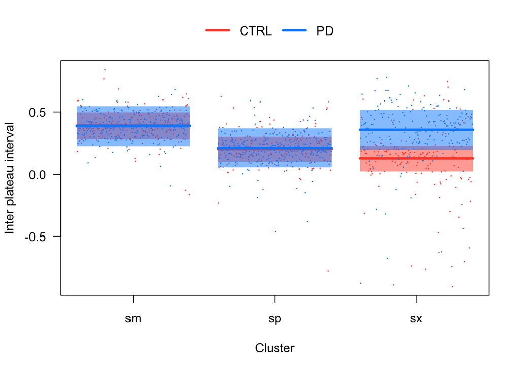

```r
visreg(m4, "cluster", by = "group", overlay = T, points = list(cex = 0.1), ylab = "Inter plateau interval", xlab = "Cluster")
```

### 3.1.1 Exploratory analysis

Add speech rate.

```r
m4 <- gam(time.lag.norm ~ s(subj,bs='re') + s(subj, cluster, bs="re") + cluster*group, data=df.nospr, method = "ML") #fit using ML

df.nospr$duration.tt <- df.nospr$duration.tt - mean(df.nospr$duration.tt) # center continues variable

summary(m5 <- gam(time.lag.norm ~ s(subj,bs='re') + s(subj, cluster, bs="re") + cluster*group + duration.tt, data=df.nospr, method = "ML"))
```

```
##
## Family: gaussian
## Link function: identity
##
## Formula:
## time.lag.norm ~ s(subj, bs = "re") + s(subj, cluster, bs = "re") +
##     cluster * group + duration.tt
##
## Parametric coefficients:
##                     Estimate Std. Error t value Pr(>|t|)
## (Intercept)        0.3620459  0.0415867   8.706  < 2e-16 ***
## clustersp         -0.0724683  0.0582971  -1.243  0.21411
## clustersx         -0.4077518  0.0587461  -6.941 6.77e-12 ***
## groupPD           -0.0187793  0.0601947  -0.312  0.75512
## duration.tt       -0.0001325  0.0000453  -2.925  0.00352 **
## clustersp:groupPD  0.0179294  0.0839086   0.214  0.83084
## clustersx:groupPD  0.2372227  0.0861201   2.755  0.00598 **
## ---
## Signif. codes:  0 '***' 0.001 '**' 0.01 '*' 0.05 '.' 0.1 ' ' 1
##
## Approximate significance of smooth terms:
##                     edf Ref.df      F p-value
## s(subj)           1.099     45  0.114   0.284
## s(subj,cluster) 116.657    131 10.771  <2e-16 ***
## ---
## Signif. codes:  0 '***' 0.001 '**' 0.01 '*' 0.05 '.' 0.1 ' ' 1
##
## R-sq.(adj) =  0.641   Deviance explained = 67.8%
## -ML = -197.3  Scale est. = 0.031949  n = 1185
```

```r
compareML(m4, m5)
```

```
## m4: time.lag.norm ~ s(subj, bs = "re") + s(subj, cluster, bs = "re") +
##     cluster * group
##
## m5: time.lag.norm ~ s(subj, bs = "re") + s(subj, cluster, bs = "re") +
##     cluster * group + duration.tt
##
## Chi-square test of ML scores
## -----
##   Model     Score Edf Difference    Df p.value Sig.
## 1    m4 -193.0361   8
## 2    m5 -197.2986   9      4.262 1.000   0.004  **
##
## AIC difference: 8.37, model m5 has lower AIC.
```

Sign. but small improvement.

Gender

```r
summary(m6 <- gam(time.lag.norm ~ s(subj,bs='re') + s(subj, cluster, bs="re") + cluster*group + duration.tt + gender, data=df.nospr, method = "ML"))
```

```
##
## Family: gaussian
## Link function: identity
##
## Formula:
## time.lag.norm ~ s(subj, bs = "re") + s(subj, cluster, bs = "re") +
##     cluster * group + duration.tt + gender
##
## Parametric coefficients:
##                     Estimate Std. Error t value Pr(>|t|)
## (Intercept)        3.379e-01  4.240e-02   7.969 4.11e-15 ***
## clustersp         -7.278e-02  5.755e-02  -1.265  0.20633
## clustersx         -4.087e-01  5.801e-02  -7.045 3.33e-12 ***
## groupPD           -1.450e-02  5.921e-02  -0.245  0.80654
## duration.tt       -1.487e-04  4.578e-05  -3.248  0.00120 **
## genderF            8.551e-02  3.988e-02   2.144  0.03225 *
## clustersp:groupPD  1.879e-02  8.284e-02   0.227  0.82058
## clustersx:groupPD  2.393e-01  8.503e-02   2.814  0.00498 **
## ---
## Signif. codes:  0 '***' 0.001 '**' 0.01 '*' 0.05 '.' 0.1 ' ' 1
##
## Approximate significance of smooth terms:
##                       edf Ref.df     F p-value
## s(subj)         1.345e-03     44 0.000   0.441
## s(subj,cluster) 1.164e+02    130 9.768  <2e-16 ***
## ---
## Signif. codes:  0 '***' 0.001 '**' 0.01 '*' 0.05 '.' 0.1 ' ' 1
##
## R-sq.(adj) =  0.641   Deviance explained = 67.8%
## -ML = -199.56  Scale est. = 0.031958  n = 1185
```

```r
compareML(m5, m6)
```

[output not shown]

Add recording.no

```r
summary(m7 <- gam(time.lag.norm ~ s(subj,bs='re') + s(subj, cluster, bs="re") + cluster*group + duration.tt + gender + recording.no, data=df.nospr, method = "ML"))
```

```
##
## Family: gaussian
## Link function: identity
##
## Formula:
## time.lag.norm ~ s(subj, bs = "re") + s(subj, cluster, bs = "re") +
##     cluster * group + duration.tt + gender + recording.no
##
## Parametric coefficients:
##                     Estimate Std. Error t value Pr(>|t|)
## (Intercept)        3.321e-01  4.356e-02   7.623 5.47e-14 ***
## clustersp         -7.252e-02  5.759e-02  -1.259  0.20823
## clustersx         -4.086e-01  5.805e-02  -7.039 3.47e-12 ***
## groupPD           -1.362e-02  5.927e-02  -0.230  0.81830
## duration.tt       -1.399e-04  4.814e-05  -2.907  0.00373 **
## genderF            8.396e-02  3.999e-02   2.099  0.03602 *
## recording.no       1.426e-04  2.411e-04   0.592  0.55427
## clustersp:groupPD  1.843e-02  8.290e-02   0.222  0.82409
## clustersx:groupPD  2.394e-01  8.509e-02   2.813  0.00500 **
## ---
## Signif. codes:  0 '***' 0.001 '**' 0.01 '*' 0.05 '.' 0.1 ' ' 1
##
## Approximate significance of smooth terms:
##                       edf Ref.df     F p-value
## s(subj)         1.309e-03     44 0.000   0.439
## s(subj,cluster) 1.164e+02    130 9.765  <2e-16 ***
## ---
## Signif. codes:  0 '***' 0.001 '**' 0.01 '*' 0.05 '.' 0.1 ' ' 1
##
## R-sq.(adj) =   0.64   Deviance explained = 67.8%
## -ML = -199.73  Scale est. = 0.031975  n = 1185
```

```r
compareML(m6, m7)
```

```
## m6: time.lag.norm ~ s(subj, bs = "re") + s(subj, cluster, bs = "re") +
##     cluster * group + duration.tt + gender
##
## m7: time.lag.norm ~ s(subj, bs = "re") + s(subj, cluster, bs = "re") +
##     cluster * group + duration.tt + gender + recording.no
##
## Chi-square test of ML scores
## -----
##   Model     Score Edf Difference    Df p.value Sig.
## 1    m6 -199.5559  10
## 2    m7 -199.7312  11      0.175 1.000   0.554
##
## AIC difference: -1.51, model m6 has lower AIC.
```

No improvement.

Add age.

```r
summary(m8 <- gam(time.lag.norm ~ s(subj,bs='re') + s(subj, cluster, bs="re") + cluster*group + duration.tt + gender + age, data=df.nospr, method = "ML"))
```

```
##
## Family: gaussian
## Link function: identity
##
## Formula:
## time.lag.norm ~ s(subj, bs = "re") + s(subj, cluster, bs = "re") +
##     cluster * group + duration.tt + gender + age
##
## Parametric coefficients:
##                     Estimate Std. Error t value Pr(>|t|)
## (Intercept)        1.516e-01  1.838e-01   0.825  0.40949
## clustersp         -7.265e-02  5.736e-02  -1.267  0.20553
## clustersx         -4.082e-01  5.781e-02  -7.061 2.99e-12 ***
## groupPD           -1.781e-02  5.909e-02  -0.301  0.76320
## duration.tt       -1.443e-04  4.595e-05  -3.142  0.00173 **
## genderF            8.504e-02  3.975e-02   2.139  0.03264 *
## age                2.738e-03  2.629e-03   1.041  0.29789
## clustersp:groupPD  1.860e-02  8.255e-02   0.225  0.82178
## clustersx:groupPD  2.382e-01  8.475e-02   2.810  0.00504 **
## ---
## Signif. codes:  0 '***' 0.001 '**' 0.01 '*' 0.05 '.' 0.1 ' ' 1
##
## Approximate significance of smooth terms:
##                       edf Ref.df     F p-value
## s(subj)           0.00159     43 0.000   0.432
## s(subj,cluster) 115.43445    129 9.794  <2e-16 ***
## ---
## Signif. codes:  0 '***' 0.001 '**' 0.01 '*' 0.05 '.' 0.1 ' ' 1
##
## R-sq.(adj) =  0.641   Deviance explained = 67.8%
## -ML = -200.1  Scale est. = 0.031957  n = 1185
```

```r
compareML(m6, m8)
```

```
## m6: time.lag.norm ~ s(subj, bs = "re") + s(subj, cluster, bs = "re") +
##     cluster * group + duration.tt + gender
##
## m8: time.lag.norm ~ s(subj, bs = "re") + s(subj, cluster, bs = "re") +
##     cluster * group + duration.tt + gender + age
##
## Chi-square test of ML scores
## -----
##   Model     Score Edf Difference    Df p.value Sig.
## 1    m6 -199.5559  10
## 2    m8 -200.0974  11      0.542 1.000   0.298
##
## AIC difference: 0.02, model m8 has lower AIC.
```

No improvement.

Add dialect.

```r
summary(m9 <- gam(time.lag.norm ~ s(subj,bs='re') + s(subj, cluster, bs="re") + cluster*group + duration.tt + gender + dialect, data=df.nospr, method = "ML"))
```

```
##
## Family: gaussian
## Link function: identity
##
## Formula:
## time.lag.norm ~ s(subj, bs = "re") + s(subj, cluster, bs = "re") +
##     cluster * group + duration.tt + gender + dialect
##
## Parametric coefficients:
##                        Estimate Std. Error t value Pr(>|t|)
## (Intercept)           3.235e-01  4.567e-02   7.084 2.55e-12 ***
## clustersp            -7.280e-02  5.736e-02  -1.269  0.20464
## clustersx            -4.088e-01  5.782e-02  -7.071 2.79e-12 ***
## groupPD              -1.402e-02  5.904e-02  -0.237  0.81233
## duration.tt          -1.486e-04  4.584e-05  -3.242  0.00122 **
## genderF               8.985e-02  4.177e-02   2.151  0.03171 *
## dialectFrisian        4.387e-02  6.262e-02   0.701  0.48373
## dialectNedersaksisch  2.871e-02  3.895e-02   0.737  0.46124
## clustersp:groupPD     1.921e-02  8.256e-02   0.233  0.81605
## clustersx:groupPD     2.395e-01  8.477e-02   2.826  0.00481 **
## ---
## Signif. codes:  0 '***' 0.001 '**' 0.01 '*' 0.05 '.' 0.1 ' ' 1
##
## Approximate significance of smooth terms:
##                       edf Ref.df     F p-value
## s(subj)         1.336e-03     42 0.000    0.38
## s(subj,cluster) 1.146e+02    128 9.835  <2e-16 ***
## ---
## Signif. codes:  0 '***' 0.001 '**' 0.01 '*' 0.05 '.' 0.1 ' ' 1
##
## R-sq.(adj) =  0.641   Deviance explained = 67.8%
## -ML =   -200  Scale est. = 0.031966  n = 1185
```

```r
compareML(m6, m9)
```

```
## m6: time.lag.norm ~ s(subj, bs = "re") + s(subj, cluster, bs = "re") +
##     cluster * group + duration.tt + gender
##
## m9: time.lag.norm ~ s(subj, bs = "re") + s(subj, cluster, bs = "re") +
##     cluster * group + duration.tt + gender + dialect
##
## Chi-square test of ML scores
## -----
##   Model     Score Edf Difference    Df p.value Sig.
## 1    m6 -199.5559  10
## 2    m9 -199.9980  12      0.442 2.000   0.643
##
## AIC difference: -0.42, model m6 has lower AIC.
```

No improvement.

#### 3.1.1.1 Visualize final model:

```r
summary(m6 <- gam(time.lag.norm ~ s(subj,bs='re') + s(subj, cluster, bs="re") + cluster*group + duration.tt + gender, data=df.nospr)) # refit using REML
```

```
##
## Family: gaussian
## Link function: identity
##
## Formula:
## time.lag.norm ~ s(subj, bs = "re") + s(subj, cluster, bs = "re") +
##     cluster * group + duration.tt + gender
##
## Parametric coefficients:
##                     Estimate Std. Error t value Pr(>|t|)
## (Intercept)        3.379e-01  4.509e-02   7.494 1.41e-13 ***
## clustersp         -7.264e-02  6.122e-02  -1.186  0.23570
## clustersx         -4.080e-01  6.165e-02  -6.618 5.78e-11 ***
## groupPD           -1.449e-02  6.295e-02  -0.230  0.81796
## duration.tt       -1.490e-04  4.622e-05  -3.224  0.00130 **
## genderF            8.533e-02  4.235e-02   2.015  0.04416 *
## clustersp:groupPD  1.852e-02  8.811e-02   0.210  0.83351
## clustersx:groupPD  2.391e-01  9.037e-02   2.646  0.00827 **
## ---
## Signif. codes:  0 '***' 0.001 '**' 0.01 '*' 0.05 '.' 0.1 ' ' 1
##
## Approximate significance of smooth terms:
##                       edf Ref.df     F p-value
## s(subj)         1.172e-05     44 0.000   0.652
## s(subj,cluster) 1.180e+02    130 9.906  <2e-16 ***
## ---
## Signif. codes:  0 '***' 0.001 '**' 0.01 '*' 0.05 '.' 0.1 ' ' 1
##
## R-sq.(adj) =  0.641   Deviance explained = 67.9%
## GCV = 0.035701  Scale est. = 0.031906  n = 1185
```

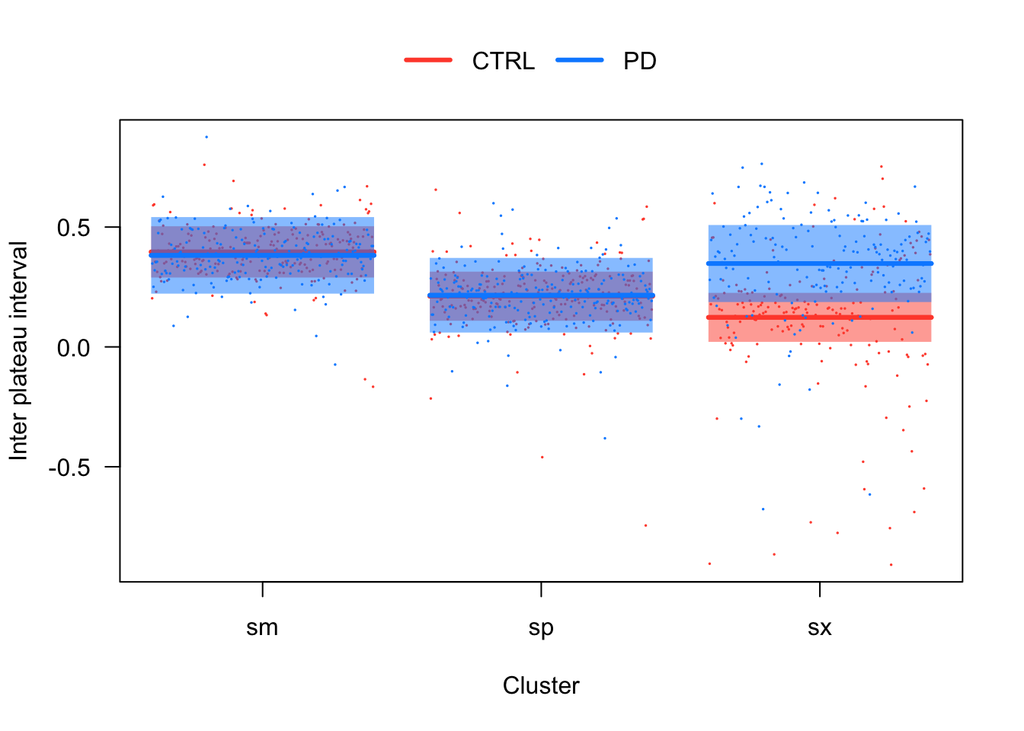

```r
visreg(m6, "cluster", by = "group", overlay = T, points = list(cex = 0.1), ylab = "Inter plateau interval", xlab = "Cluster")
```

#### 3.1.1.2 Pairwise comparisons

```r
emmeans(m6, specs = pairwise ~ group|cluster, nesting = NULL)
```

```
## $emmeans
## cluster = sm:
##  group  emmean     SE   df lower.CL upper.CL
##  CTRL   0.3805 0.0331 1059   0.3156   0.4455
##  PD     0.3661 0.0362 1059   0.2951   0.4370
##
## cluster = sp:
##  group  emmean     SE   df lower.CL upper.CL
##  CTRL   0.3079 0.0328 1059   0.2436   0.3722
##  PD     0.3119 0.0350 1059   0.2434   0.3805
##
## cluster = sx:
##  group  emmean     SE   df lower.CL upper.CL
##  CTRL  -0.0274 0.0335 1059  -0.0931   0.0382
##  PD     0.1972 0.0399 1059   0.1189   0.2754
##
## Results are averaged over the levels of: gender, subj
## Confidence level used: 0.95
##
## $contrasts
## cluster = sm:
##  contrast  estimate     SE   df t.ratio p.value
##  CTRL - PD  0.01449 0.0629 1059  0.230  0.8180
##
## cluster = sp:
##  contrast  estimate     SE   df t.ratio p.value
##  CTRL - PD -0.00403 0.0620 1059 -0.065  0.9482
##
## cluster = sx:
##  contrast  estimate     SE   df t.ratio p.value
##  CTRL - PD -0.22462 0.0653 1059 -3.442  0.0006
##
## Results are averaged over the levels of: gender, subj
```

### 3.1.2 Check effect of tremor and akinetic on time.lag.norm for PD group only

Base model:

```r
summary(m6.PD <- gam(time.lag.norm ~ s(subj,bs='re') + s(subj, cluster, bs="re") + cluster + duration.tt + gender, data=df.nospr[df.nospr$group == "PD",], method = "ML"))
```

```
##
## Family: gaussian
## Link function: identity
##
## Formula:
## time.lag.norm ~ s(subj, bs = "re") + s(subj, cluster, bs = "re") +
##     cluster + duration.tt + gender
##
## Parametric coefficients:
##               Estimate Std. Error t value Pr(>|t|)
## (Intercept)  3.377e-01  3.128e-02  10.794  < 2e-16 ***
## clustersp   -5.353e-02  4.152e-02  -1.289   0.1979
## clustersx   -1.716e-01  4.350e-02  -3.944 9.14e-05 ***
## duration.tt -1.103e-04  6.116e-05  -1.804   0.0718 .
## genderF      2.901e-02  4.209e-02   0.689   0.4911
## ---
## Signif. codes:  0 '***' 0.001 '**' 0.01 '*' 0.05 '.' 0.1 ' ' 1
##
## Approximate significance of smooth terms:
##                       edf Ref.df   F p-value
## s(subj)         3.529e-04     21 0.0   0.827
## s(subj,cluster) 5.045e+01     61 5.9  <2e-16 ***
## ---
## Signif. codes:  0 '***' 0.001 '**' 0.01 '*' 0.05 '.' 0.1 ' ' 1
##
## R-sq.(adj) =  0.464   Deviance explained = 51.6%
## -ML = -171.79  Scale est. = 0.025667  n = 559
```

```r
summary(m7.PD <- gam(time.lag.norm ~ s(subj,bs='re') + s(subj, cluster, bs="re") + cluster + duration.tt + gender + tremor, data=df.nospr[df.nospr$group == "PD",], method = "ML"))
```

```
##
## Family: gaussian
## Link function: identity
##
## Formula:
## time.lag.norm ~ s(subj, bs = "re") + s(subj, cluster, bs = "re") +
##     cluster + duration.tt + gender + tremor
##
## Parametric coefficients:
##              Estimate Std. Error t value Pr(>|t|)
## (Intercept)  0.320340   0.033694   9.507  < 2e-16 ***
## clustersp   -0.053164   0.040985  -1.297   0.1952
## clustersx   -0.172352   0.042952  -4.013 6.92e-05 ***
## duration.tt -0.000111   0.000061  -1.819   0.0695 .
## genderF      0.032503   0.041640   0.781   0.4354
## tremor       0.011256   0.008775   1.283   0.2002
## ---
## Signif. codes:  0 '***' 0.001 '**' 0.01 '*' 0.05 '.' 0.1 ' ' 1
##
## Approximate significance of smooth terms:
##                       edf Ref.df     F p-value
## s(subj)         2.065e-04     20 0.000   0.852
## s(subj,cluster) 4.934e+01     60 5.824  <2e-16 ***
## ---
## Signif. codes:  0 '***' 0.001 '**' 0.01 '*' 0.05 '.' 0.1 ' ' 1
##
## R-sq.(adj) =  0.464   Deviance explained = 51.6%
## -ML = -172.6  Scale est. = 0.025678  n = 559
```

```r
compareML(m6.PD, m7.PD)
```

```
## m6.PD: time.lag.norm ~ s(subj, bs = "re") + s(subj, cluster, bs = "re") +
##     cluster + duration.tt + gender
##
## m7.PD: time.lag.norm ~ s(subj, bs = "re") + s(subj, cluster, bs = "re") +
##     cluster + duration.tt + gender + tremor
##
## Chi-square test of ML scores
## -----
##   Model     Score Edf Difference    Df p.value Sig.
## 1 m6.PD -171.7891   7
## 2 m7.PD -172.6036   8      0.814 1.000   0.202
##
## AIC difference: -0.15, model m6.PD has lower AIC.
```

No improvement.

Add akinetic as a fixed effect.

```r
summary(m8.PD <- gam(time.lag.norm ~ s(subj,bs='re') + s(subj, cluster, bs="re") + cluster + duration.tt + gender + akinetic, data=df.nospr[df.nospr$group == "PD",], method = "ML"))
```

```
##
## Family: gaussian
## Link function: identity
##
## Formula:
## time.lag.norm ~ s(subj, bs = "re") + s(subj, cluster, bs = "re") +
##     cluster + duration.tt + gender + akinetic
##
## Parametric coefficients:
##               Estimate Std. Error t value Pr(>|t|)
## (Intercept)  3.610e-01  3.503e-02  10.307   <2e-16 ***
## clustersp   -5.200e-02  4.096e-02  -1.269   0.2049
## clustersx   -1.721e-01  4.291e-02  -4.010    7e-05 ***
## duration.tt -1.066e-04  6.106e-05  -1.745   0.0816 .
## genderF      3.859e-02  4.206e-02   0.918   0.3593
## akinetic    -1.921e-02  1.360e-02  -1.413   0.1584
## ---
## Signif. codes:  0 '***' 0.001 '**' 0.01 '*' 0.05 '.' 0.1 ' ' 1
##
## Approximate significance of smooth terms:
##                       edf Ref.df     F p-value
## s(subj)         2.052e-04     20 0.000   0.852
## s(subj,cluster) 4.935e+01     60 5.828  <2e-16 ***
## ---
## Signif. codes:  0 '***' 0.001 '**' 0.01 '*' 0.05 '.' 0.1 ' ' 1
##
## R-sq.(adj) =  0.464   Deviance explained = 51.6%
## -ML = -172.78  Scale est. = 0.025667  n = 559
```

```r
compareML(m6.PD, m8.PD)
```

```
## m6.PD: time.lag.norm ~ s(subj, bs = "re") + s(subj, cluster, bs = "re") +
##     cluster + duration.tt + gender
##
## m8.PD: time.lag.norm ~ s(subj, bs = "re") + s(subj, cluster, bs = "re") +
##     cluster + duration.tt + gender + akinetic
##
## Chi-square test of ML scores
## -----
##   Model     Score Edf Difference    Df p.value Sig.
## 1 m6.PD -171.7891   7
## 2 m8.PD -172.7778   8      0.989 1.000   0.160
##
## AIC difference: 0.08, model m8.PD has lower AIC.
```

No improvement.